# Exploratory Data Analysis

Author

Owen Simon

# Introduction

## Business Problem

Many potential borrowers lack sufficient credit histories, making it difficult for Home Credit to accurately assess their creditworthiness. This creates a challenge in extending loans to unbanked individuals while managing default risk. To continue expanding financial inclusion responsibly, Home Credit must rely on alternative data to assess repayment risk for these applicants.

## EDA Objective

The goal of this exploratory data analysis (EDA) is to develop an initial understanding of the applicant data used by Home Credit, with a focus on identifying patterns, relationships, and data quality issues that may influence loan default risk. Specifically, this analysis examines the distribution of key applicant characteristics, explores relationships between predictor variables and the `TARGET` outcome (yes/no loan default), and highlights potential challenges such as missing values, class imbalance, and outliers. Insights from this EDA will inform feature selection, data preprocessing, and modeling decisions aimed at improving credit risk assessment for applicants with limited or no traditional credit history.

# Data Exploration

## Setup

```r
# Load libraries
library(tidyverse)
library(tidyr)
library(dplyr)
library(gt)

data_dir <- "data-files"

# Read primary datasets
dict <- read_csv(file.path(data_dir, "HomeCredit_columns_description.csv"))
test  <- read_csv(file.path(data_dir, "application_test.csv"))
train <- read_csv(file.path(data_dir, "application_train.csv"))
```

## 1 - Majority Class Analysis

```r
target_proportion <- train |>
  count(TARGET) |>
  mutate(Proportion = round(n / sum(n), 4)) |>
  rename(Default = TARGET,
         Count = n)

gt(target_proportion)
```

| Default | Count | Proportion |
| --- | --- | --- |
| 0 | 282686 | 0.9193 |
| 1 | 24825 | 0.0807 |

A majority-class model that always predicts non-default would achieve an accuracy of approximately 92%.

## 2 - Correlation Analysis

```r
# Count types of all variables except TARGET and SK_ID_CURR
var_types <- train |>
  select(-TARGET, -SK_ID_CURR) |>
  summarise(across(everything(), ~ class(.))) |>
  pivot_longer(everything(), names_to = "Variable", values_to = "Data_Type") |>
  count(Data_Type, name = "Count")

gt(var_types)
```

| Data_Type | Count |
| --- | --- |
| character | 16 |
| numeric | 104 |

### 2.1 - Numeric Variables

```r
numeric_summary <- lapply(
  names(train |> select(where(is.numeric), -TARGET, -SK_ID_CURR)),
  function(x) {
    data.frame(
      Predictor = x,
      Correlation_with_Target = round(cor(train[[x]], train$TARGET, use = "complete.obs"), 4)
    )
  }
) |> bind_rows() |>
  arrange(desc(abs(Correlation_with_Target)))

gt(numeric_summary)
```

| Predictor | Correlation_with_Target |
| --- | --- |
| EXT_SOURCE_3 | -0.1789 |
| EXT_SOURCE_2 | -0.1605 |
| EXT_SOURCE_1 | -0.1553 |
| DAYS_BIRTH | 0.0782 |
| REGION_RATING_CLIENT_W_CITY | 0.0609 |
| REGION_RATING_CLIENT | 0.0589 |
| DAYS_LAST_PHONE_CHANGE | 0.0552 |
| DAYS_ID_PUBLISH | 0.0515 |
| REG_CITY_NOT_WORK_CITY | 0.0510 |
| FLAG_EMP_PHONE | 0.0460 |
| DAYS_EMPLOYED | -0.0449 |
| REG_CITY_NOT_LIVE_CITY | 0.0444 |
| FLAG_DOCUMENT_3 | 0.0443 |
| FLOORSMAX_AVG | -0.0440 |
| FLOORSMAX_MEDI | -0.0438 |
| FLOORSMAX_MODE | -0.0432 |
| DAYS_REGISTRATION | 0.0420 |
| AMT_GOODS_PRICE | -0.0396 |
| OWN_CAR_AGE | 0.0376 |
| REGION_POPULATION_RELATIVE | -0.0372 |
| ELEVATORS_AVG | -0.0342 |
| ELEVATORS_MEDI | -0.0339 |
| FLOORSMIN_AVG | -0.0336 |
| FLOORSMIN_MEDI | -0.0334 |
| LIVINGAREA_AVG | -0.0330 |
| FLOORSMIN_MODE | -0.0327 |
| LIVINGAREA_MEDI | -0.0327 |
| TOTALAREA_MODE | -0.0326 |
| LIVE_CITY_NOT_WORK_CITY | 0.0325 |
| DEF_30_CNT_SOCIAL_CIRCLE | 0.0322 |

[output cut: 74 more lines]

The numeric variables with the highest correlation to the target variable are `EXT_SOURCE_3`, `EXT_SOURCE_2`, and `EXT_SOURCE_1`, which are all normalized scores from external data sources.

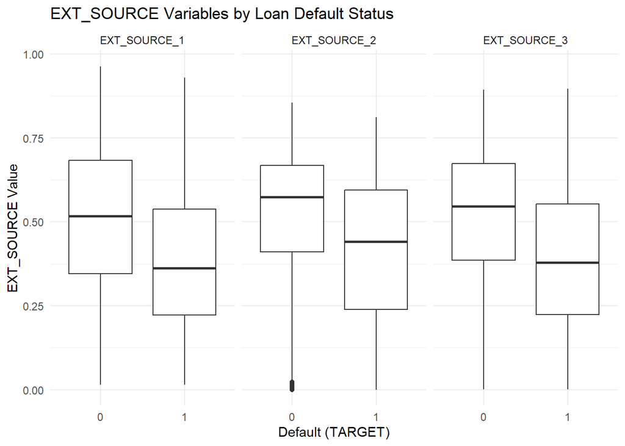

```r
train |>
  select(TARGET, EXT_SOURCE_1, EXT_SOURCE_2, EXT_SOURCE_3) |>
  pivot_longer(
    cols = starts_with("EXT_SOURCE"),
    names_to = "Source",
    values_to = "Value"
  ) |>
  ggplot(aes(x = factor(TARGET), y = Value)) +
  geom_boxplot() +
  facet_wrap(~ Source, scales = "fixed") +  # fixed y-axis across facets
  labs(
    x = "Default (TARGET)",
    y = "EXT_SOURCE Value",
    title = "EXT_SOURCE Variables by Loan Default Status"
  ) +
  theme_minimal()
```

Across all three `EXT_SOURCE_` variables, non-defaulted applicants (`TARGET` = 0) exhibit higher median values and overall distributions compared to defaulted applicants (`TARGET` = 1). This consistent separation suggests a negative association between `EXT_SOURCE_` scores and loan default risk, indicating that higher external risk scores are associated with lower likelihood of default. Notably, `EXT_SOURCE_2` shows a large number of outliers near 0, all of which occur for non-defaulted applicants (`TARGET` = 0), suggesting unusual low scores among borrowers who ultimately did not default.

### 2.2 - Categorical Variables

```r
# Summarize categorical variables
cat_summary <- lapply(
  names(train |> select(where(is.character), -TARGET, -SK_ID_CURR)),
  function(x) {
    rates <- train |> group_by(.data[[x]]) |>
      summarise(Default_Rate = mean(TARGET, na.rm = TRUE), .groups = "drop")

    data.frame(
      Predictor = x,
      Max_Proportion_Diff = max(rates$Default_Rate) - min(rates$Default_Rate)
    )
  }
) |> bind_rows() |>
  arrange(desc(Max_Proportion_Diff))

gt(cat_summary)
```

| Predictor | Max_Proportion_Diff |
| --- | --- |
| NAME_INCOME_TYPE | 0.400000000 |
| ORGANIZATION_TYPE | 0.126290017 |
| OCCUPATION_TYPE | 0.123220857 |
| CODE_GENDER | 0.101419203 |
| NAME_FAMILY_STATUS | 0.099445844 |
| NAME_EDUCATION_TYPE | 0.090984047 |
| NAME_HOUSING_TYPE | 0.057406394 |
| WALLSMATERIAL_MODE | 0.049761201 |
| NAME_TYPE_SUITE | 0.044125518 |
| HOUSETYPE_MODE | 0.031967102 |
| NAME_CONTRACT_TYPE | 0.028675836 |
| FONDKAPREMONT_MODE | 0.027993041 |
| EMERGENCYSTATE_MODE | 0.026141383 |
| FLAG_OWN_CAR | 0.012564966 |
| WEEKDAY_APPR_PROCESS_START | 0.005932676 |
| FLAG_OWN_REALTY | 0.003633517 |

`NAME_INCOME_TYPE` shows the strongest separation in default rates across its categories, suggesting it may be the most informative categorical predictor.

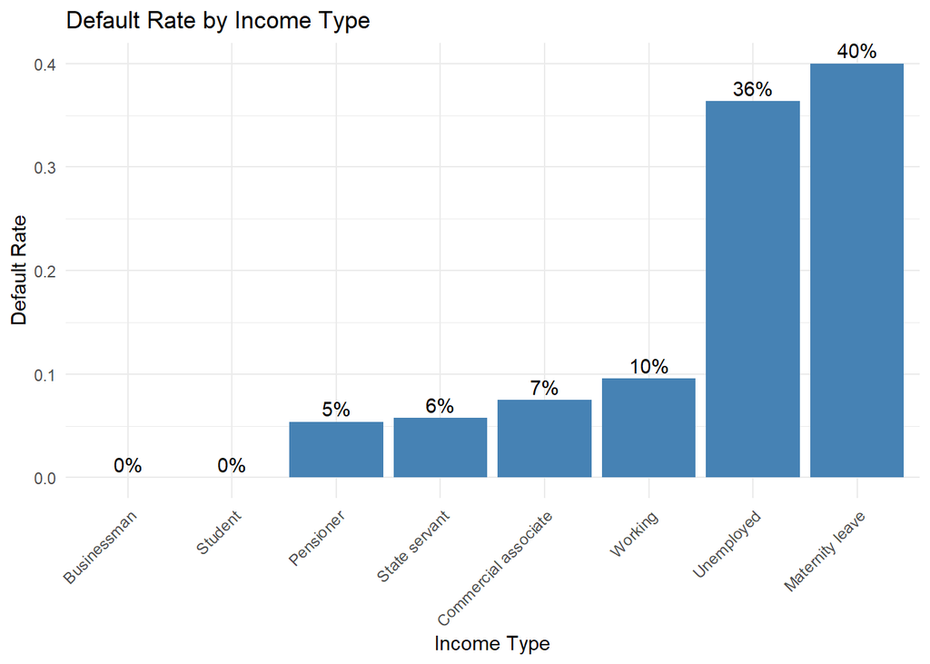

```r
train |>
  group_by(NAME_INCOME_TYPE) |>
  summarise(
    Default_Rate = mean(TARGET, na.rm = TRUE),
    Count = n(),
    .groups = "drop"
  ) |>
  ggplot(aes(x = reorder(NAME_INCOME_TYPE, Default_Rate), y = Default_Rate)) +
  geom_col(fill = "steelblue") +
  geom_text(aes(label = scales::percent(Default_Rate, accuracy = 1)),
            vjust = -0.38) +
  labs(
    title = "Default Rate by Income Type",
    x = "Income Type",
    y = "Default Rate"
  ) +
  theme_minimal() +
  theme(axis.text.x = element_text(angle = 45, hjust = 1))
```

## 3 - Missing Data

```r
# Add a placeholder TARGET to test
test <- test |>
  mutate(TARGET = NA)

# Combine train and test
combined <- bind_rows(
  train |>mutate(dataset = "train"),
  test  |> mutate(dataset = "test")
)
```

Before examining missing values, the training and test datasets were combined into a single dataset. A placeholder TARGET column was added to the test set, and a dataset indicator was created to track the origin of each row. This setup ensures that missing value analysis can be performed consistently across both datasets.

```r
#count NAs
count_missings <- function(x) sum(is.na(x))

missing_summary <- combined |>
  select(-TARGET, -SK_ID_CURR) |>  # exclude TARGET and ID
  summarize_all(~ sum(is.na(.))) |>
  pivot_longer(
    cols = everything(),
    names_to = "Variable",
    values_to = "Count"
  ) |>
  filter(Count > 0) |>
  mutate(Proportion = round(Count / nrow(combined), 4)) |>
  arrange(desc(Count))

gt(missing_summary) |>
  tab_header(
    title = "Missing Data Summary",
  )
```

Missing Data Summary

| Variable | Count | Proportion |
| --- | --- | --- |
| COMMONAREA_AVG | 248360 | 0.6971 |
| COMMONAREA_MODE | 248360 | 0.6971 |
| COMMONAREA_MEDI | 248360 | 0.6971 |
| NONLIVINGAPARTMENTS_AVG | 246861 | 0.6929 |
| NONLIVINGAPARTMENTS_MODE | 246861 | 0.6929 |
| NONLIVINGAPARTMENTS_MEDI | 246861 | 0.6929 |
| FONDKAPREMONT_MODE | 243092 | 0.6824 |
| LIVINGAPARTMENTS_AVG | 242979 | 0.6820 |
| LIVINGAPARTMENTS_MODE | 242979 | 0.6820 |
| LIVINGAPARTMENTS_MEDI | 242979 | 0.6820 |
| FLOORSMIN_AVG | 241108 | 0.6768 |
| FLOORSMIN_MODE | 241108 | 0.6768 |
| FLOORSMIN_MEDI | 241108 | 0.6768 |
| YEARS_BUILD_AVG | 236306 | 0.6633 |
| YEARS_BUILD_MODE | 236306 | 0.6633 |
| YEARS_BUILD_MEDI | 236306 | 0.6633 |
| OWN_CAR_AGE | 235241 | 0.6603 |
| LANDAREA_AVG | 210844 | 0.5918 |
| LANDAREA_MODE | 210844 | 0.5918 |
| LANDAREA_MEDI | 210844 | 0.5918 |
| BASEMENTAREA_AVG | 207584 | 0.5827 |
| BASEMENTAREA_MODE | 207584 | 0.5827 |
| BASEMENTAREA_MEDI | 207584 | 0.5827 |
| NONLIVINGAREA_AVG | 195766 | 0.5495 |
| NONLIVINGAREA_MODE | 195766 | 0.5495 |
| NONLIVINGAREA_MEDI | 195766 | 0.5495 |
| EXT_SOURCE_1 | 193910 | 0.5443 |
| ELEVATORS_AVG | 189080 | 0.5307 |
| ELEVATORS_MODE | 189080 | 0.5307 |
| ELEVATORS_MEDI | 189080 | 0.5307 |
| WALLSMATERIAL_MODE | 180234 | 0.5059 |
| APARTMENTS_AVG | 179948 | 0.5051 |
| APARTMENTS_MODE | 179948 | 0.5051 |
| APARTMENTS_MEDI | 179948 | 0.5051 |
| ENTRANCES_AVG | 178407 | 0.5008 |
| ENTRANCES_MODE | 178407 | 0.5008 |
| ENTRANCES_MEDI | 178407 | 0.5008 |
| HOUSETYPE_MODE | 177916 | 0.4994 |
| LIVINGAREA_AVG | 177902 | 0.4994 |
| LIVINGAREA_MODE | 177902 | 0.4994 |
| LIVINGAREA_MEDI | 177902 | 0.4994 |
| FLOORSMAX_AVG | 176341 | 0.4950 |
| FLOORSMAX_MODE | 176341 | 0.4950 |
| FLOORSMAX_MEDI | 176341 | 0.4950 |
| YEARS_BEGINEXPLUATATION_AVG | 172863 | 0.4852 |
| YEARS_BEGINEXPLUATATION_MODE | 172863 | 0.4852 |
| YEARS_BEGINEXPLUATATION_MEDI | 172863 | 0.4852 |
| TOTALAREA_MODE | 171055 | 0.4801 |
| EMERGENCYSTATE_MODE | 167964 | 0.4715 |
| OCCUPATION_TYPE | 111996 | 0.3144 |
| EXT_SOURCE_3 | 69633 | 0.1955 |
| AMT_REQ_CREDIT_BUREAU_HOUR | 47568 | 0.1335 |
| AMT_REQ_CREDIT_BUREAU_DAY | 47568 | 0.1335 |
| AMT_REQ_CREDIT_BUREAU_WEEK | 47568 | 0.1335 |
| AMT_REQ_CREDIT_BUREAU_MON | 47568 | 0.1335 |
| AMT_REQ_CREDIT_BUREAU_QRT | 47568 | 0.1335 |
| AMT_REQ_CREDIT_BUREAU_YEAR | 47568 | 0.1335 |
| NAME_TYPE_SUITE | 2203 | 0.0062 |
| OBS_30_CNT_SOCIAL_CIRCLE | 1050 | 0.0029 |
| DEF_30_CNT_SOCIAL_CIRCLE | 1050 | 0.0029 |
| OBS_60_CNT_SOCIAL_CIRCLE | 1050 | 0.0029 |
| DEF_60_CNT_SOCIAL_CIRCLE | 1050 | 0.0029 |
| EXT_SOURCE_2 | 668 | 0.0019 |
| AMT_GOODS_PRICE | 278 | 0.0008 |
| AMT_ANNUITY | 36 | 0.0001 |
| CNT_FAM_MEMBERS | 2 | 0.0000 |
| DAYS_LAST_PHONE_CHANGE | 1 | 0.0000 |

47 variables included in the missing data summary share a common description: “Normalized information about building where the client lives, What is average (_AVG suffix), modus (_MODE suffix), median (_MEDI suffix) apartment size, common area, living area, age of building, number of elevators, number of entrances, state of the building, number of floor.” For these characteristics, NULL values can reasonably be interpreted as the feature being absent or not applicable. For example, a NULL in BASEMENTAREA_AVG likely indicates that the residence does not have a basement. Because the variables are normalized on a 0–1 scale, replacing NULLs with 0 is both intuitive and semantically meaningful: 0 effectively encodes “feature not present,” preserving the interpretation of the normalized score without introducing artificial averages.

```r
building_level_variables <- dict |>
  filter(Table == "application_{train|test}.csv",
         Description == "Normalized information about building where the client lives, What is average (_AVG suffix), modus (_MODE suffix), median (_MEDI suffix) apartment size, common area, living area, age of building, number of elevators, number of entrances, state of the building, number of floor") |>
  pull(Row)

missing_summary_2 <- combined |>
  select(-TARGET, -SK_ID_CURR, -all_of(building_level_variables)) |>  # exclude TARGET, ID and building-level variables
  summarize_all(~ sum(is.na(.))) |>
  pivot_longer(
    cols = everything(),
    names_to = "Variable",
    values_to = "Count"
  ) |>
  filter(Count > 0) |>
  mutate(Proportion = round(Count / nrow(combined), 4)) |>
  arrange(desc(Count))

gt(missing_summary_2) |>
  tab_header(
    title = "Missing Data Summary",
    subtitle = "Excluding the building-level variables",
  )
```

Missing Data Summary

Excluding the building-level variables

| Variable | Count | Proportion |
| --- | --- | --- |
| OWN_CAR_AGE | 235241 | 0.6603 |
| EXT_SOURCE_1 | 193910 | 0.5443 |
| OCCUPATION_TYPE | 111996 | 0.3144 |
| EXT_SOURCE_3 | 69633 | 0.1955 |
| AMT_REQ_CREDIT_BUREAU_HOUR | 47568 | 0.1335 |
| AMT_REQ_CREDIT_BUREAU_DAY | 47568 | 0.1335 |
| AMT_REQ_CREDIT_BUREAU_WEEK | 47568 | 0.1335 |
| AMT_REQ_CREDIT_BUREAU_MON | 47568 | 0.1335 |
| AMT_REQ_CREDIT_BUREAU_QRT | 47568 | 0.1335 |
| AMT_REQ_CREDIT_BUREAU_YEAR | 47568 | 0.1335 |
| NAME_TYPE_SUITE | 2203 | 0.0062 |
| OBS_30_CNT_SOCIAL_CIRCLE | 1050 | 0.0029 |
| DEF_30_CNT_SOCIAL_CIRCLE | 1050 | 0.0029 |
| OBS_60_CNT_SOCIAL_CIRCLE | 1050 | 0.0029 |
| DEF_60_CNT_SOCIAL_CIRCLE | 1050 | 0.0029 |
| EXT_SOURCE_2 | 668 | 0.0019 |
| AMT_GOODS_PRICE | 278 | 0.0008 |
| AMT_ANNUITY | 36 | 0.0001 |
| CNT_FAM_MEMBERS | 2 | 0.0000 |
| DAYS_LAST_PHONE_CHANGE | 1 | 0.0000 |

Other variables in the summary, such as `OWN_CAR_AGE` (which indicates the age of the client’s car), may be NULL because the client does not own a car. In such cases, NULL values should be replaced with 0.

For variables where NULL represents genuinely missing information rather than the absence of a feature, missing values should be imputed to avoid losing information. Numeric variables should be imputed using the median, while categorical variables should use the most frequent value (mode).

Variables with substantial missingness may be candidates for removal; however, some variables, such as `EXT_SOURCE_1`, are highly predictive of the target. In these cases, imputing missing values is preferable to dropping the variable, preserving its predictive value in modeling.

## 4 - Data Problems

### 4.1 - Normalized Variables

```r
# Select variables marked as normalized in the data dictionary
normalized_tag <- dict |>
  filter(Table == "application_{train|test}.csv",
         Special == "normalized") |>
  pull(Row)

# Subset train
normalized <- train |>
  select(all_of(normalized_tag))

# Check data types
var_types <- sapply(normalized, class)
var_types
```

```
  REGION_POPULATION_RELATIVE                 EXT_SOURCE_1
                   "numeric"                    "numeric"
                EXT_SOURCE_2                 EXT_SOURCE_3
                   "numeric"                    "numeric"
              APARTMENTS_AVG             BASEMENTAREA_AVG
                   "numeric"                    "numeric"
 YEARS_BEGINEXPLUATATION_AVG              YEARS_BUILD_AVG
                   "numeric"                    "numeric"
              COMMONAREA_AVG                ELEVATORS_AVG
                   "numeric"                    "numeric"
               ENTRANCES_AVG                FLOORSMAX_AVG
                   "numeric"                    "numeric"
               FLOORSMIN_AVG                 LANDAREA_AVG
                   "numeric"                    "numeric"
        LIVINGAPARTMENTS_AVG               LIVINGAREA_AVG
                   "numeric"                    "numeric"
     NONLIVINGAPARTMENTS_AVG            NONLIVINGAREA_AVG
                   "numeric"                    "numeric"
             APARTMENTS_MODE            BASEMENTAREA_MODE
                   "numeric"                    "numeric"
YEARS_BEGINEXPLUATATION_MODE             YEARS_BUILD_MODE
                   "numeric"                    "numeric"
             COMMONAREA_MODE               ELEVATORS_MODE
                   "numeric"                    "numeric"
              ENTRANCES_MODE               FLOORSMAX_MODE
                   "numeric"                    "numeric"
              FLOORSMIN_MODE                LANDAREA_MODE
                   "numeric"                    "numeric"
       LIVINGAPARTMENTS_MODE              LIVINGAREA_MODE
                   "numeric"                    "numeric"
    NONLIVINGAPARTMENTS_MODE           NONLIVINGAREA_MODE
                   "numeric"                    "numeric"
             APARTMENTS_MEDI            BASEMENTAREA_MEDI
                   "numeric"                    "numeric"
YEARS_BEGINEXPLUATATION_MEDI             YEARS_BUILD_MEDI
                   "numeric"                    "numeric"
             COMMONAREA_MEDI               ELEVATORS_MEDI
                   "numeric"                    "numeric"
              ENTRANCES_MEDI               FLOORSMAX_MEDI
                   "numeric"                    "numeric"
              FLOORSMIN_MEDI                LANDAREA_MEDI
                   "numeric"                    "numeric"
       LIVINGAPARTMENTS_MEDI              LIVINGAREA_MEDI
                   "numeric"                    "numeric"
    NONLIVINGAPARTMENTS_MEDI           NONLIVINGAREA_MEDI
                   "numeric"                    "numeric"
          FONDKAPREMONT_MODE               HOUSETYPE_MODE
                 "character"                  "character"
              TOTALAREA_MODE           WALLSMATERIAL_MODE
                   "numeric"                  "character"
         EMERGENCYSTATE_MODE
                 "character"
```

Most variables labeled as “normalized” in the data dictionary are numeric and can be interpreted on a 0–1 scale. However, four of the 47 building-level variables, `FONDKAPREMONT_MODE`, `HOUSETYPE_MODE`, `WALLSMATERIAL_MODE`, and `EMERGENCYSTATE_MODE`, are actually categorical (character) variables, not numeric. These variables are therefore incorrectly labeled as “normalized.”

Previously, it was suggested that all building-level variables have their NULLs imputed with 0. For these four categorical variables, however, imputing NULLs with 0 is inappropriate and would misrepresent the data. Missing values should instead be handled using mode imputation or other categorical encoding strategies to preserve their meaning.

```r
# Update Normalized Variables
normalized <- normalized |>
  select(-FONDKAPREMONT_MODE,
         -HOUSETYPE_MODE,
         -WALLSMATERIAL_MODE,
         -EMERGENCYSTATE_MODE)

summary(normalized)
```

```
 REGION_POPULATION_RELATIVE  EXT_SOURCE_1     EXT_SOURCE_2     EXT_SOURCE_3
 Min.   :0.00029            Min.   :0.015    Min.   :0.0000   Min.   :0.001
 1st Qu.:0.01001            1st Qu.:0.334    1st Qu.:0.3925   1st Qu.:0.371
 Median :0.01885            Median :0.506    Median :0.5660   Median :0.535
 Mean   :0.02087            Mean   :0.502    Mean   :0.5144   Mean   :0.511
 3rd Qu.:0.02866            3rd Qu.:0.675    3rd Qu.:0.6636   3rd Qu.:0.669
 Max.   :0.07251            Max.   :0.963    Max.   :0.8550   Max.   :0.896
                            NA's   :173378   NA's   :660      NA's   :60965
 APARTMENTS_AVG   BASEMENTAREA_AVG YEARS_BEGINEXPLUATATION_AVG YEARS_BUILD_AVG
 Min.   :0.000    Min.   :0.000    Min.   :0.000               Min.   :0.000
 1st Qu.:0.058    1st Qu.:0.044    1st Qu.:0.977               1st Qu.:0.687
 Median :0.088    Median :0.076    Median :0.982               Median :0.755
 Mean   :0.117    Mean   :0.088    Mean   :0.978               Mean   :0.752
 3rd Qu.:0.148    3rd Qu.:0.112    3rd Qu.:0.987               3rd Qu.:0.823
 Max.   :1.000    Max.   :1.000    Max.   :1.000               Max.   :1.000
 NA's   :156061   NA's   :179943   NA's   :150007              NA's   :204488
 COMMONAREA_AVG   ELEVATORS_AVG    ENTRANCES_AVG    FLOORSMAX_AVG
 Min.   :0.000    Min.   :0.000    Min.   :0.000    Min.   :0.000
 1st Qu.:0.008    1st Qu.:0.000    1st Qu.:0.069    1st Qu.:0.167
 Median :0.021    Median :0.000    Median :0.138    Median :0.167
 Mean   :0.045    Mean   :0.079    Mean   :0.150    Mean   :0.226
 3rd Qu.:0.052    3rd Qu.:0.120    3rd Qu.:0.207    3rd Qu.:0.333
 Max.   :1.000    Max.   :1.000    Max.   :1.000    Max.   :1.000
 NA's   :214865   NA's   :163891   NA's   :154828   NA's   :153020
 FLOORSMIN_AVG     LANDAREA_AVG    LIVINGAPARTMENTS_AVG LIVINGAREA_AVG
 Min.   :0.000    Min.   :0.000    Min.   :0.000        Min.   :0.000
 1st Qu.:0.083    1st Qu.:0.019    1st Qu.:0.050        1st Qu.:0.045
 Median :0.208    Median :0.048    Median :0.076        Median :0.074
 Mean   :0.232    Mean   :0.066    Mean   :0.101        Mean   :0.107
 3rd Qu.:0.375    3rd Qu.:0.086    3rd Qu.:0.121        3rd Qu.:0.130
 Max.   :1.000    Max.   :1.000    Max.   :1.000        Max.   :1.000
 NA's   :208642   NA's   :182590   NA's   :210199       NA's   :154350
 NONLIVINGAPARTMENTS_AVG NONLIVINGAREA_AVG APARTMENTS_MODE  BASEMENTAREA_MODE
 Min.   :0.000           Min.   :0.000     Min.   :0.000    Min.   :0.000
 1st Qu.:0.000           1st Qu.:0.000     1st Qu.:0.052    1st Qu.:0.041
 Median :0.000           Median :0.004     Median :0.084    Median :0.075
 Mean   :0.009           Mean   :0.028     Mean   :0.114    Mean   :0.088
 3rd Qu.:0.004           3rd Qu.:0.028     3rd Qu.:0.144    3rd Qu.:0.112
 Max.   :1.000           Max.   :1.000     Max.   :1.000    Max.   :1.000
 NA's   :213514          NA's   :169682    NA's   :156061   NA's   :179943
```

[output cut: 49 more lines]

```
 Min.   :0.000    Min.   :0.000         Min.   :0.000
 1st Qu.:0.019    1st Qu.:0.051         1st Qu.:0.046
 Median :0.049    Median :0.076         Median :0.075
 Mean   :0.067    Mean   :0.102         Mean   :0.109
 3rd Qu.:0.087    3rd Qu.:0.123         3rd Qu.:0.130
 Max.   :1.000    Max.   :1.000         Max.   :1.000
 NA's   :182590   NA's   :210199        NA's   :154350
 NONLIVINGAPARTMENTS_MEDI NONLIVINGAREA_MEDI TOTALAREA_MODE
 Min.   :0.000            Min.   :0.000      Min.   :0.000
 1st Qu.:0.000            1st Qu.:0.000      1st Qu.:0.041
 Median :0.000            Median :0.003      Median :0.069
 Mean   :0.009            Mean   :0.028      Mean   :0.103
 3rd Qu.:0.004            3rd Qu.:0.027      3rd Qu.:0.128
 Max.   :1.000            Max.   :1.000      Max.   :1.000
 NA's   :213514           NA's   :169682     NA's   :148431
```

After excluding the four incorrectly labeled categorical variables, all remaining variables tagged as “normalized” are numeric and have observed values bounded between 0 and 1. This confirms that these variables are consistently scaled and that their normalization aligns with the data dictionary’s description.

### 4.2 - Remaining Numeric Variables

```r
# all numeric variables (EXCLUDING normalized since they have been checked)
numeric_error_check <- train |>
  select(
    where(is.numeric),
    -TARGET,
    -SK_ID_CURR,
    -all_of(names(normalized))
  )

summary(numeric_error_check)
```

```
  CNT_CHILDREN     AMT_INCOME_TOTAL      AMT_CREDIT       AMT_ANNUITY
 Min.   : 0.0000   Min.   :    25650   Min.   :  45000   Min.   :  1616
 1st Qu.: 0.0000   1st Qu.:   112500   1st Qu.: 270000   1st Qu.: 16524
 Median : 0.0000   Median :   147150   Median : 513531   Median : 24903
 Mean   : 0.4171   Mean   :   168798   Mean   : 599026   Mean   : 27109
 3rd Qu.: 1.0000   3rd Qu.:   202500   3rd Qu.: 808650   3rd Qu.: 34596
 Max.   :19.0000   Max.   :117000000   Max.   :4050000   Max.   :258026
                                                         NA's   :12
 AMT_GOODS_PRICE     DAYS_BIRTH     DAYS_EMPLOYED    DAYS_REGISTRATION
 Min.   :  40500   Min.   :-25229   Min.   :-17912   Min.   :-24672
 1st Qu.: 238500   1st Qu.:-19682   1st Qu.: -2760   1st Qu.: -7480
 Median : 450000   Median :-15750   Median : -1213   Median : -4504
 Mean   : 538396   Mean   :-16037   Mean   : 63815   Mean   : -4986
 3rd Qu.: 679500   3rd Qu.:-12413   3rd Qu.:  -289   3rd Qu.: -2010
 Max.   :4050000   Max.   : -7489   Max.   :365243   Max.   :     0
 NA's   :278
 DAYS_ID_PUBLISH  OWN_CAR_AGE       FLAG_MOBIL FLAG_EMP_PHONE
 Min.   :-7197   Min.   : 0.00    Min.   :0    Min.   :0.0000
 1st Qu.:-4299   1st Qu.: 5.00    1st Qu.:1    1st Qu.:1.0000
 Median :-3254   Median : 9.00    Median :1    Median :1.0000
 Mean   :-2994   Mean   :12.06    Mean   :1    Mean   :0.8199
 3rd Qu.:-1720   3rd Qu.:15.00    3rd Qu.:1    3rd Qu.:1.0000
 Max.   :    0   Max.   :91.00    Max.   :1    Max.   :1.0000
                 NA's   :202929
 FLAG_WORK_PHONE  FLAG_CONT_MOBILE   FLAG_PHONE       FLAG_EMAIL
 Min.   :0.0000   Min.   :0.0000   Min.   :0.0000   Min.   :0.00000
 1st Qu.:0.0000   1st Qu.:1.0000   1st Qu.:0.0000   1st Qu.:0.00000
 Median :0.0000   Median :1.0000   Median :0.0000   Median :0.00000
 Mean   :0.1994   Mean   :0.9981   Mean   :0.2811   Mean   :0.05672
 3rd Qu.:0.0000   3rd Qu.:1.0000   3rd Qu.:1.0000   3rd Qu.:0.00000
 Max.   :1.0000   Max.   :1.0000   Max.   :1.0000   Max.   :1.00000

 CNT_FAM_MEMBERS  REGION_RATING_CLIENT REGION_RATING_CLIENT_W_CITY
 Min.   : 1.000   Min.   :1.000        Min.   :1.000
 1st Qu.: 2.000   1st Qu.:2.000        1st Qu.:2.000
 Median : 2.000   Median :2.000        Median :2.000
 Mean   : 2.153   Mean   :2.052        Mean   :2.032
 3rd Qu.: 3.000   3rd Qu.:2.000        3rd Qu.:2.000
 Max.   :20.000   Max.   :3.000        Max.   :3.000
 NA's   :2
```

[output cut: 81 more lines]

```
 Min.   :0.000              Min.   : 0.000            Min.   :  0.000
 1st Qu.:0.000              1st Qu.: 0.000            1st Qu.:  0.000
 Median :0.000              Median : 0.000            Median :  0.000
 Mean   :0.034              Mean   : 0.267            Mean   :  0.265
 3rd Qu.:0.000              3rd Qu.: 0.000            3rd Qu.:  0.000
 Max.   :8.000              Max.   :27.000            Max.   :261.000
 NA's   :41519              NA's   :41519             NA's   :41519
 AMT_REQ_CREDIT_BUREAU_YEAR
 Min.   : 0.0
 1st Qu.: 0.0
 Median : 1.0
 Mean   : 1.9
 3rd Qu.: 3.0
 Max.   :25.0
 NA's   :41519
```

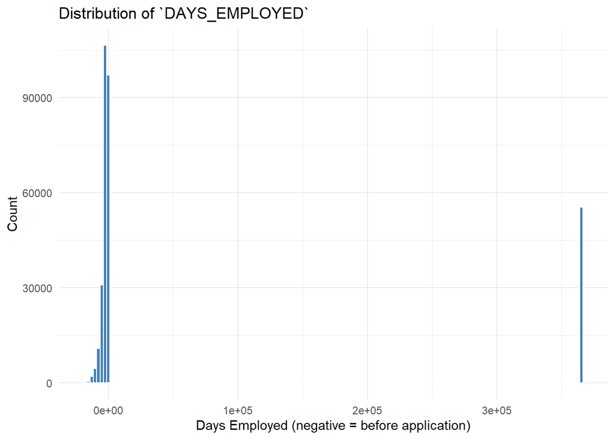

```r
ggplot(train, aes(x = DAYS_EMPLOYED)) +
  geom_histogram(bins = 150, fill = "steelblue", color = "white") +
  labs(
    title = "Distribution of `DAYS_EMPLOYED`",
    x = "Days Employed (negative = before application)",
    y = "Count"
  ) +
  theme_minimal()
```

For modeling, `DAYS_EMPLOYED` can be transformed so that 0 represents unemployment, with all other values converted to positive durations using the absolute value. This makes the variable easier to interpret, as it no longer measures time relative to the loan application. Other `DAYS_` variables could benefit from similar transformations; for example, DAYS_BIRTH can be converted into years by taking the absolute value and dividing by 365 to create an `AGE` variable.

### 4.3 - Categorical

```r
categorical_summary <- train |>
  select(where(is.character)) |>
  pivot_longer(cols = everything(), names_to = "variable", values_to = "level") |>
  group_by(variable, level) |>
  summarise(n = n(), .groups = "drop") |>
  arrange(variable, desc(n))

gt(categorical_summary)
```

| variable | level | n |
| --- | --- | --- |
| CODE_GENDER | F | 202448 |
| CODE_GENDER | M | 105059 |
| CODE_GENDER | XNA | 4 |
| EMERGENCYSTATE_MODE | No | 159428 |
| EMERGENCYSTATE_MODE | NA | 145755 |
| EMERGENCYSTATE_MODE | Yes | 2328 |
| FLAG_OWN_CAR | N | 202924 |
| FLAG_OWN_CAR | Y | 104587 |
| FLAG_OWN_REALTY | Y | 213312 |
| FLAG_OWN_REALTY | N | 94199 |
| FONDKAPREMONT_MODE | NA | 210295 |
| FONDKAPREMONT_MODE | reg oper account | 73830 |
| FONDKAPREMONT_MODE | reg oper spec account | 12080 |
| FONDKAPREMONT_MODE | not specified | 5687 |
| FONDKAPREMONT_MODE | org spec account | 5619 |
| HOUSETYPE_MODE | NA | 154297 |
| HOUSETYPE_MODE | block of flats | 150503 |
| HOUSETYPE_MODE | specific housing | 1499 |
| HOUSETYPE_MODE | terraced house | 1212 |
| NAME_CONTRACT_TYPE | Cash loans | 278232 |
| NAME_CONTRACT_TYPE | Revolving loans | 29279 |
| NAME_EDUCATION_TYPE | Secondary / secondary special | 218391 |
| NAME_EDUCATION_TYPE | Higher education | 74863 |
| NAME_EDUCATION_TYPE | Incomplete higher | 10277 |
| NAME_EDUCATION_TYPE | Lower secondary | 3816 |
| NAME_EDUCATION_TYPE | Academic degree | 164 |
| NAME_FAMILY_STATUS | Married | 196432 |
| NAME_FAMILY_STATUS | Single / not married | 45444 |
| NAME_FAMILY_STATUS | Civil marriage | 29775 |
| NAME_FAMILY_STATUS | Separated | 19770 |

[output cut: 116 more lines]

The dataset contains several variations of NULL or missing-like values, such as ‘Unknown’, ‘XNA’, and ‘NA’. Additionally, some categorical levels are rare, such as ‘Unemployed’, ‘Student’, ‘Businessman’, and ‘Maternity Leave’ in `NAME_INCOME_TYPE`. While these categories may exhibit distinct default rates, their low frequency can lead to unstable estimates. As a result, rare levels may need to be grouped with similar categories or treated separately to avoid introducing noise or overfitting in downstream models.

## 5 - Aggregate Additional Data

```r
# Load additional datasets
pos_cash <- read_csv(file.path(data_dir, "POS_CASH_balance.csv"))
bureau <- read_csv(file.path(data_dir, "bureau.csv"))
bureau_balance <- read_csv(file.path(data_dir, "bureau_balance.csv"))
cred_card <- read_csv(file.path(data_dir, "credit_card_balance.csv"))
install <- read_csv(file.path(data_dir, "installments_payments.csv"))
prev_app <- read_csv(file.path(data_dir, "previous_application.csv"))
```

These datasets provide additional information about clients’ financial histories beyond the primary application data. `POS_CASH` records track point-of-sale cash loans, the bureau datasets contain historical credit information from other lenders, credit card balances summarize revolving credit usage, previous applications detail past loan requests, and installment payments capture repayment patterns on prior loans.

```r
# Aggregate POS_CASH_balance per client to summarize loan counts, installments, and default metrics
pos_cash_client <- pos_cash |>
  group_by(SK_ID_CURR) |>
  summarise(
    POS_CASH_LOANS = n_distinct(SK_ID_PREV),
    MONTHS_HISTORY = n(),
    CNT_INSTALMENT_MEAN = mean(CNT_INSTALMENT, na.rm = TRUE),
    CNT_INSTALMENT_FUTURE_MEAN = mean(CNT_INSTALMENT_FUTURE, na.rm = TRUE),
    SK_DPD_MEAN = mean(SK_DPD, na.rm = TRUE),
    SK_DPD_DEF_MEAN = mean(SK_DPD_DEF, na.rm = TRUE),
    .groups = "drop"
  )

# Aggregate bureau_balance per bureau credit, then summarize per client including credit counts, totals, and averages
bureau_balance_agg <- bureau_balance |>
  group_by(SK_ID_BUREAU) |>
  summarise(
    MONTHS_BUREAU = n(),
    STATUS_MOST_COMMON = names(sort(table(STATUS), decreasing = TRUE))[1],
    .groups = "drop"
  )

bureau_client <- bureau |>
  left_join(bureau_balance_agg, by = "SK_ID_BUREAU") |>
  group_by(SK_ID_CURR) |>
  summarise(
    BUREAU_CREDITS = n_distinct(SK_ID_BUREAU),
    CREDIT_ACTIVE_COUNT = sum(CREDIT_ACTIVE == "Active", na.rm = TRUE),
    AMT_CREDIT_SUM = sum(AMT_CREDIT_SUM, na.rm = TRUE),
    AMT_CREDIT_SUM_OVERDUE = sum(AMT_CREDIT_SUM_OVERDUE, na.rm = TRUE),
    AMT_CREDIT_MAX_OVERDUE = max(AMT_CREDIT_MAX_OVERDUE, na.rm = TRUE),
    MONTHS_BUREAU_MEAN = mean(MONTHS_BUREAU, na.rm = TRUE),
    .groups = "drop"
  )

# Aggregate credit card balances per client to capture loan counts, balances, credit limits, payments, and default metrics
cred_card_client <- cred_card |>
  group_by(SK_ID_CURR) |>
  summarise(
    CC_LOANS = n_distinct(SK_ID_PREV),
    MONTHS_CC = n(),
    AMT_BALANCE_MEAN = mean(AMT_BALANCE, na.rm = TRUE),
    AMT_CREDIT_LIMIT_MEAN = mean(AMT_CREDIT_LIMIT_ACTUAL, na.rm = TRUE),
    AMT_PAYMENT_MEAN = mean(AMT_PAYMENT_CURRENT, na.rm = TRUE),
    SK_DPD_MEAN = mean(SK_DPD, na.rm = TRUE),
    SK_DPD_DEF_MEAN = mean(SK_DPD_DEF, na.rm = TRUE),
    .groups = "drop"
  )

# Aggregate previous applications per client to summarize number of applications, average amounts, and approval/refusal counts
prev_app_client <- prev_app |>
  group_by(SK_ID_CURR) |>
  summarise(
    NUM_PREV_APPS = n(),
    AMT_APPLICATION_MEAN = mean(AMT_APPLICATION, na.rm = TRUE),
    AMT_CREDIT_MEAN = mean(AMT_CREDIT, na.rm = TRUE),
    NUM_APPROVED = sum(NAME_CONTRACT_STATUS == "Approved", na.rm = TRUE),
    NUM_REFUSED = sum(NAME_CONTRACT_STATUS == "Refused", na.rm = TRUE),
    .groups = "drop"
  )

# Aggregate installment payments per client to summarize total installments, payments, and average payment delays
install_client <- install |>
  group_by(SK_ID_CURR) |>
  summarise(
    NUM_INSTALLMENTS = n(),
    AMT_INSTALMENT_TOTAL = sum(AMT_INSTALMENT, na.rm = TRUE),
    AMT_PAYMENT_TOTAL = sum(AMT_PAYMENT, na.rm = TRUE),
    DAYS_LATE_MEAN = mean(DAYS_ENTRY_PAYMENT - DAYS_INSTALMENT, na.rm = TRUE),
    .groups = "drop"
  )
```

Each additional dataset was aggregated to the client level (`SK_ID_CURR`) to summarize key financial behaviors, including counts of past loans and applications, average balances and credit limits, repayment patterns, delinquency measures, and approval outcomes, creating a comprehensive client-level view of historical financial activity.

```r
# Merge all client-level summaries
train_augmented <- train |>
  left_join(pos_cash_client, by = "SK_ID_CURR") |>
  left_join(bureau_client, by = "SK_ID_CURR") |>
  left_join(cred_card_client, by = "SK_ID_CURR") |>
  left_join(prev_app_client, by = "SK_ID_CURR") |>
  left_join(install_client, by = "SK_ID_CURR")

test_augmented <- test |>
  left_join(pos_cash_client, by = "SK_ID_CURR") |>
  left_join(bureau_client, by = "SK_ID_CURR") |>
  left_join(cred_card_client, by = "SK_ID_CURR") |>
  left_join(prev_app_client, by = "SK_ID_CURR") |>
  left_join(install_client, by = "SK_ID_CURR")
```

Now that all data has been aggregated to the client level, these aggregates are merged with the primary training and test datasets. This creates augmented datasets containing both application features and summarized historical financial behavior, enabling more comprehensive modeling of default risk.

## 6 - Additional Correlation Analysis

```r
numeric_summary <- lapply(
  names(train_augmented |>
          select(where(~ is.numeric(.) | is.integer(.)), -TARGET, -SK_ID_CURR)),
  function(x) {
    data.frame(
      Predictor = x,
      Correlation_with_Target = round(
        cor(train_augmented[[x]], train_augmented$TARGET, use = "complete.obs"), 4
      )
    )
  }
) |>
  bind_rows() |>
  arrange(desc(abs(Correlation_with_Target)))

gt(numeric_summary)
```

| Predictor | Correlation_with_Target |
| --- | --- |
| EXT_SOURCE_3 | -0.1789 |
| EXT_SOURCE_2 | -0.1605 |
| EXT_SOURCE_1 | -0.1553 |
| AMT_BALANCE_MEAN | 0.0872 |
| MONTHS_BUREAU_MEAN | -0.0802 |
| DAYS_BIRTH | 0.0782 |
| CREDIT_ACTIVE_COUNT | 0.0671 |
| NUM_REFUSED | 0.0645 |
| REGION_RATING_CLIENT_W_CITY | 0.0609 |
| MONTHS_CC | -0.0605 |
| REGION_RATING_CLIENT | 0.0589 |
| DAYS_LAST_PHONE_CHANGE | 0.0552 |
| DAYS_ID_PUBLISH | 0.0515 |
| REG_CITY_NOT_WORK_CITY | 0.0510 |
| FLAG_EMP_PHONE | 0.0460 |
| DAYS_EMPLOYED | -0.0449 |
| REG_CITY_NOT_LIVE_CITY | 0.0444 |
| FLAG_DOCUMENT_3 | 0.0443 |
| FLOORSMAX_AVG | -0.0440 |
| FLOORSMAX_MEDI | -0.0438 |
| FLOORSMAX_MODE | -0.0432 |
| DAYS_REGISTRATION | 0.0420 |
| POS_CASH_LOANS | -0.0405 |
| AMT_GOODS_PRICE | -0.0396 |
| OWN_CAR_AGE | 0.0376 |
| REGION_POPULATION_RELATIVE | -0.0372 |
| MONTHS_HISTORY | -0.0356 |
| ELEVATORS_AVG | -0.0342 |
| ELEVATORS_MEDI | -0.0339 |
| FLOORSMIN_AVG | -0.0336 |

[output cut: 102 more lines]

The numeric variables with the highest correlation to the target variable are still `EXT_SOURCE_3`, `EXT_SOURCE_2`, and `EXT_SOURCE_1`; however, newly aggregated features such as `AMT_BALANCE_MEAN` and `MONTHS_BUREAU_MEAN` also exhibit notable correlations. `AMT_BALANCE_MEAN` captures the average outstanding balance on a client’s previous credit card accounts, while `MONTHS_BUREAU_MEAN` represents the average number of months of credit history per client, calculated from their individual bureau accounts.

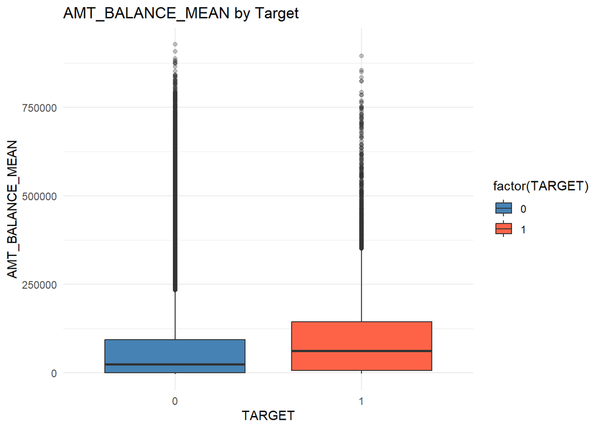

```r
# Prepare data
plot_data <- train_augmented |>
  select(TARGET, AMT_BALANCE_MEAN, MONTHS_BUREAU_MEAN)

# AMT_BALANCE_MEAN box plot
ggplot(plot_data, aes(x = factor(TARGET), y = AMT_BALANCE_MEAN, fill = factor(TARGET))) +
  geom_boxplot(outlier.alpha = 0.3) +
  scale_fill_manual(values = c("0" = "steelblue", "1" = "tomato")) +
  labs(
    title = "AMT_BALANCE_MEAN by Target",
    x = "TARGET",
    y = "AMT_BALANCE_MEAN"
  ) +
  theme_minimal()
```

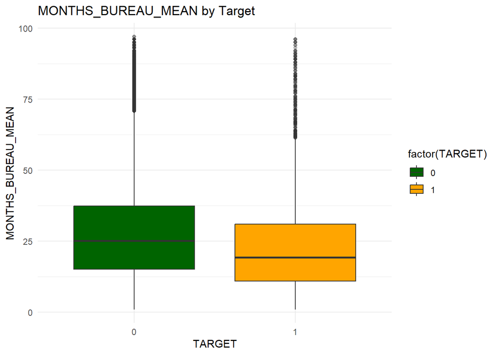

```r
# MONTHS_BUREAU_MEAN box plot
ggplot(plot_data, aes(x = factor(TARGET), y = MONTHS_BUREAU_MEAN, fill = factor(TARGET))) +
  geom_boxplot(outlier.alpha = 0.3) +
  scale_fill_manual(values = c("0" = "darkgreen", "1" = "orange")) +
  labs(
    title = "MONTHS_BUREAU_MEAN by Target",
    x = "TARGET",
    y = "MONTHS_BUREAU_MEAN"
  ) +
  theme_minimal()
```

For `AMT_BALANCE_MEAN`, defaulted applicants (`TARGET` = 1) exhibit higher median balances and generally higher overall distributions compared to non-defaulted applicants (`TARGET` = 0). This pattern suggests a positive association between average credit card balances and loan default risk, indicating that clients carrying higher average balances are more likely to default.

In contrast, for `MONTHS_BUREAU_MEAN`, non-defaulted applicants (`TARGET` = 0) show higher median values and overall distributions relative to defaulted applicants (`TARGET` = 1). This indicates a negative association between the average length of a client’s credit history reported to the bureau and default risk, with longer credit histories corresponding to lower likelihood of default.

# Key Findings

This exploratory analysis reveals that the dataset is highly imbalanced, with approximately 92% of applicants not defaulting, indicating that accuracy alone is not an appropriate evaluation metric. Strong relationships between the target and several predictors were identified, most notably the `EXT_SOURCE_` variables, where higher values are consistently associated with lower default risk. Among categorical predictors, `NAME_INCOME_TYPE` exhibits meaningful variation in default rates, particularly for categories such as “Unemployed” and “Maternity Leave.”

The analysis also highlights important data quality considerations. Missing values are widespread, especially among building-level features, and require context-dependent handling through zero imputation or median and mode replacement. Several variables labeled as normalized were found to be categorical, underscoring the need for careful data interpretation. Additionally, rare categorical levels may produce unstable estimates and should be evaluated thoughtfully in downstream modeling.

Finally, incorporating aggregated transactional data provides additional predictive insight. Features derived from credit card balances and bureau history demonstrate meaningful associations with default risk, reinforcing the value of combining application-level data with historical financial behavior. Overall, this EDA identifies key predictors, data challenges, and feature opportunities that inform subsequent preprocessing and modeling decisions for loan default prediction.